[figure not shown]

## mlcourse.ai – Open Machine Learning Course

Authors: [Yury Kashnitskiy](https://yorko.github.io) and [Maxim Keremet](https://www.linkedin.com/in/maximkeremet/). Translated and edited by [Artem Trunov](https://www.linkedin.com/in/datamove/), and [Aditya Soni](https://www.linkedin.com/in/aditya-soni-0505a9124/). This material is subject to the terms and conditions of the [Creative Commons CC BY-NC-SA 4.0](https://creativecommons.org/licenses/by-nc-sa/4.0/) license. Free use is permitted for any non-commercial purpose.

# Assignment #1. Spring 2019

## Exploratory Data Analysis (EDA) of US flights (using Pandas, Matplotlib & Seaborn)

[figure not shown]

Prior to working on the assignment, you'd better check out the corresponding course material:

- [Exploratory data analysis with Pandas](https://nbviewer.jupyter.org/github/Yorko/mlcourse_open/blob/master/jupyter_english/topic01_pandas_data_analysis/topic1_pandas_data_analysis.ipynb?flush_cache=true), the same as an interactive web-based [Kaggle Kernel](https://www.kaggle.com/kashnitsky/topic-1-exploratory-data-analysis-with-pandas)
- [Visualization: from Simple Distributions to Dimensionality Reduction](https://mlcourse.ai/notebooks/blob/master/jupyter_english/topic02_visual_data_analysis/topic2_visual_data_analysis.ipynb?flush_cache=true), the same as a [Kaggle Kernel](https://www.kaggle.com/kashnitsky/topic-2-visual-data-analysis-in-python)
- [Overview of Seaborn, Matplotlib and Plotly libraries](https://mlcourse.ai/notebooks/blob/master/jupyter_english/topic02_visual_data_analysis/topic2_additional_seaborn_matplotlib_plotly.ipynb?flush_cache=true), the same as a [Kaggle Kernel](https://www.kaggle.com/kashnitsky/topic-2-part-2-seaborn-and-plotly)
- first lectures in [this](https://www.youtube.com/watch?v=QKTuw4PNOsU&list=PLVlY_7IJCMJeRfZ68eVfEcu-UcN9BbwiX) YouTube playlist
- you can also practice with demo assignments, which are simpler and already shared with solutions: [A1 demo](https://www.kaggle.com/kashnitsky/a1-demo-pandas-and-uci-adult-dataset), solution, [A2 demo](https://www.kaggle.com/kashnitsky/a2-demo-analyzing-cardiovascular-data), solution

### Your task is to:

1. write code and perform computations in the cells below
2. choose answers in the [webform](https://docs.google.com/forms/d/1Q_5rY7Paed4Xc_THtrfE3OSaB3sJerYuJ7NCHtqRbKs). Solutions will be shared only with those who've filled in this form
3. submit answers with some email and **remember it**! This will be your ID during the course. Specify your real full name in the form as well (no nicks allowed in the final top-100 rating). If in doubt, you can re-submit the form till the deadline for A1, no problem, but stick to only one email.

### How to get help

In [ODS Slack](https://opendatascience.slack.com) (if you still don't have access, fill in the [form](https://docs.google.com/forms/d/1BMqcUc-hIQXa0HB_Q2Oa8vWBtGHXk8a6xo5gPnMKYKA/edit) mentioned on the mlcourse.ai main page), we have a channel **#mlcourse_ai_news** with announcements from the course team. You can discuss the course content freely in the **#mlcourse_ai** channel (we still have a huge Russian-speaking group, they have a separate channel **#mlcourse_ai_rus**).

Here's how you reply in a thread (press this dialog icon to drill down into a thread):

[figure not shown]

Please stick to special threads for your questions:

- [#a1_q1-5](https://opendatascience.slack.com/archives/C91N8TL83/p1549882488049500) for questions 1-5 below
- [#a1_q6-10](https://opendatascience.slack.com/archives/C91N8TL83/p1549882494049700) for questions 6-10 below
- [#a1_q11-15](https://opendatascience.slack.com/archives/C91N8TL83/p1549882499049900) for questions 11-15 below
- [#a1_q16-20](https://opendatascience.slack.com/archives/C91N8TL83/p1549882508050200) for questions 16-20 below

Help each other without sharing correct code and answers. Our TA Maxim @maximkeremet is there to help (only in the mentioned threads, do not write to him directly).

Lastly, you can save useful messages by pinning them, further you can find pinned items on the top, just below the channel name:

[figure not shown]

```python
import numpy as np
import pandas as pd
# pip install seaborn
import seaborn as sns
import matplotlib.pyplot as plt
```

- Download the data [archive](http://stat-computing.org/dataexpo/2009/2008.csv.bz2) (Archived ~ 114 Mb, unzipped - ~ 690 Mb, [alternative link](https://drive.google.com/file/d/1C5nTzitvJ0ho2Crpqnghg9r2yq98Xxun/view?usp=sharing)). No need to unzip - pandas can unzip on the fly.
- Place it in the "../../data" folder, or change the path below according to your location.
- The dataset has information about carriers and flights between US airports during the year 2008.
- Column description is available [here](http://www.transtats.bts.gov/Fields.asp?Table_ID=236). Visit this site to find ex. meaning of flight cancellation codes.

Consider the following terms we use:

- unique flight - a record (row) in the dataset
- completed flight = flight that is not cancelled (Cancelled==0 in the dataset)
- flight code - a combination of ['UniqueCarrier','FlightNum'], i.e. UA52
- airport code - a three letter airport alias from 'Origin or 'Dest' columns

**Reading data into memory and creating a Pandas `DataFrame` object**

(This may take a while, be patient)

We are not going to read in the whole dataset. In order to reduce memory footprint, we instead load only needed columns and cast them to suitable data types.

```python
dtype = {'DayOfWeek': np.uint8, 'DayofMonth': np.uint8, 'Month': np.uint8 ,
         'Cancelled': np.uint8, 'Year': np.uint16, 'FlightNum': np.uint16 ,
         'Distance': np.uint16, 'UniqueCarrier': str, 'CancellationCode': str,
         'Origin': str, 'Dest': str, 'ArrDelay': np.float16,
         'DepDelay': np.float16, 'CarrierDelay': np.float16,
         'WeatherDelay': np.float16, 'NASDelay': np.float16,
         'SecurityDelay': np.float16, 'LateAircraftDelay': np.float16,
         'DepTime': np.float16}
```

```python
%%time
# change the path if needed
path = '../../data/2008.csv.bz2'
flights_df = pd.read_csv(path, usecols=dtype.keys(), dtype=dtype)
```

```
CPU times: user 34.8 s, sys: 558 ms, total: 35.4 s
Wall time: 35.4 s
```

**Check the number of rows and columns and print column names.**

```python
print(flights_df.shape)
print(flights_df.columns)
```

```
(7009728, 19)
Index(['Year', 'Month', 'DayofMonth', 'DayOfWeek', 'DepTime', 'UniqueCarrier',
       'FlightNum', 'ArrDelay', 'DepDelay', 'Origin', 'Dest', 'Distance',
       'Cancelled', 'CancellationCode', 'CarrierDelay', 'WeatherDelay',
       'NASDelay', 'SecurityDelay', 'LateAircraftDelay'],
      dtype='object')
```

**Print first 5 rows of the dataset.**

```python
flights_df.head()
```

|  | Year | Month | DayofMonth | DayOfWeek | DepTime | UniqueCarrier | FlightNum | ArrDelay | DepDelay | Origin | Dest | Distance | Cancelled | CancellationCode | CarrierDelay | WeatherDelay | NASDelay | SecurityDelay | LateAircraftDelay |
| --- | --- | --- | --- | --- | --- | --- | --- | --- | --- | --- | --- | --- | --- | --- | --- | --- | --- | --- | --- |
| 0 | 2008 | 1 | 3 | 4 | 2003.0 | WN | 335 | -14.0 | 8.0 | IAD | TPA | 810 | 0 | NaN | NaN | NaN | NaN | NaN | NaN |
| 1 | 2008 | 1 | 3 | 4 | 754.0 | WN | 3231 | 2.0 | 19.0 | IAD | TPA | 810 | 0 | NaN | NaN | NaN | NaN | NaN | NaN |
| 2 | 2008 | 1 | 3 | 4 | 628.0 | WN | 448 | 14.0 | 8.0 | IND | BWI | 515 | 0 | NaN | NaN | NaN | NaN | NaN | NaN |
| 3 | 2008 | 1 | 3 | 4 | 926.0 | WN | 1746 | -6.0 | -4.0 | IND | BWI | 515 | 0 | NaN | NaN | NaN | NaN | NaN | NaN |
| 4 | 2008 | 1 | 3 | 4 | 1829.0 | WN | 3920 | 34.0 | 34.0 | IND | BWI | 515 | 0 | NaN | 2.0 | 0.0 | 0.0 | 0.0 | 32.0 |

**Transpose the frame to see all features at once.**

```python
flights_df.head().T
```

|  | 0 | 1 | 2 | 3 | 4 |
| --- | --- | --- | --- | --- | --- |
| Year | 2008 | 2008 | 2008 | 2008 | 2008 |
| Month | 1 | 1 | 1 | 1 | 1 |
| DayofMonth | 3 | 3 | 3 | 3 | 3 |
| DayOfWeek | 4 | 4 | 4 | 4 | 4 |
| DepTime | 2003 | 754 | 628 | 926 | 1829 |
| UniqueCarrier | WN | WN | WN | WN | WN |
| FlightNum | 335 | 3231 | 448 | 1746 | 3920 |
| ArrDelay | -14 | 2 | 14 | -6 | 34 |
| DepDelay | 8 | 19 | 8 | -4 | 34 |
| Origin | IAD | IAD | IND | IND | IND |
| Dest | TPA | TPA | BWI | BWI | BWI |
| Distance | 810 | 810 | 515 | 515 | 515 |
| Cancelled | 0 | 0 | 0 | 0 | 0 |
| CancellationCode | NaN | NaN | NaN | NaN | NaN |
| CarrierDelay | NaN | NaN | NaN | NaN | 2 |
| WeatherDelay | NaN | NaN | NaN | NaN | 0 |
| NASDelay | NaN | NaN | NaN | NaN | 0 |
| SecurityDelay | NaN | NaN | NaN | NaN | 0 |
| LateAircraftDelay | NaN | NaN | NaN | NaN | 32 |

**Examine data types of all features and total dataframe size in memory.**

```python
flights_df.info()
```

```
<class 'pandas.core.frame.DataFrame'>
RangeIndex: 7009728 entries, 0 to 7009727
Data columns (total 19 columns):
Year                 uint16
Month                uint8
DayofMonth           uint8
DayOfWeek            uint8
DepTime              float16
UniqueCarrier        object
FlightNum            uint16
ArrDelay             float16
DepDelay             float16
Origin               object
Dest                 object
Distance             uint16
Cancelled            uint8
CancellationCode     object
CarrierDelay         float16
WeatherDelay         float16
NASDelay             float16
SecurityDelay        float16
LateAircraftDelay    float16
dtypes: float16(8), object(4), uint16(3), uint8(4)
memory usage: 387.7+ MB
```

**Get basic statistics of each feature.**

```python
flights_df.describe().T
```

|  | count | mean | std | min | 25% | 50% | 75% | max |
| --- | --- | --- | --- | --- | --- | --- | --- | --- |
| Year | 7009728.0 | 2008.000000 | 0.000000 | 2008.0 | 2008.0 | 2008.0 | 2008.0 | 2008.0 |
| Month | 7009728.0 | 6.375130 | 3.406737 | 1.0 | 3.0 | 6.0 | 9.0 | 12.0 |
| DayofMonth | 7009728.0 | 15.728015 | 8.797068 | 1.0 | 8.0 | 16.0 | 23.0 | 31.0 |
| DayOfWeek | 7009728.0 | 3.924182 | 1.988259 | 1.0 | 2.0 | 4.0 | 6.0 | 7.0 |
| DepTime | 6873482.0 | NaN | NaN | 1.0 | 928.0 | 1325.0 | 1728.0 | 2400.0 |
| FlightNum | 7009728.0 | 2224.200105 | 1961.715999 | 1.0 | 622.0 | 1571.0 | 3518.0 | 9743.0 |
| ArrDelay | 6855029.0 | NaN | NaN | -519.0 | -10.0 | -2.0 | 12.0 | 2460.0 |
| DepDelay | 6873482.0 | NaN | NaN | -534.0 | -4.0 | -1.0 | 8.0 | 2468.0 |
| Distance | 7009728.0 | 726.387029 | 562.101803 | 11.0 | 325.0 | 581.0 | 954.0 | 4962.0 |
| Cancelled | 7009728.0 | 0.019606 | 0.138643 | 0.0 | 0.0 | 0.0 | 0.0 | 1.0 |
| CarrierDelay | 1524735.0 | NaN | NaN | 0.0 | 0.0 | 0.0 | 16.0 | 2436.0 |
| WeatherDelay | 1524735.0 | NaN | NaN | 0.0 | 0.0 | 0.0 | 0.0 | 1352.0 |
| NASDelay | 1524735.0 | NaN | NaN | 0.0 | 0.0 | 6.0 | 21.0 | 1357.0 |
| SecurityDelay | 1524735.0 | NaN | NaN | 0.0 | 0.0 | 0.0 | 0.0 | 392.0 |
| LateAircraftDelay | 1524735.0 | NaN | NaN | 0.0 | 0.0 | 0.0 | 26.0 | 1316.0 |

**Count unique Carriers and plot their relative share of flights:**

```python
flights_df['UniqueCarrier'].nunique()
```

```
20
```

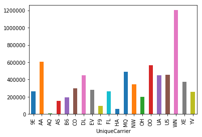

```python
flights_df.groupby('UniqueCarrier').size().plot(kind='bar');
```

**We can also *group by* category/categories in order to calculate different aggregated statistics.**

**For example, finding top-3 flight codes, that have the largest total distance travelled in year 2008.**

```python
flights_df.groupby(['UniqueCarrier','FlightNum'])['Distance'].sum().sort_values(
    ascending=False).iloc[:3]
```

```
UniqueCarrier  FlightNum
CO             15           1796244.0
               14           1796244.0
UA             52           1789722.0
Name: Distance, dtype: float64
```

**Another way:**

```python
flights_df.groupby(['UniqueCarrier','FlightNum'])\
  .agg({'Distance': [np.mean, np.sum, 'count'],
        'Cancelled': np.sum})\
  .sort_values(('Distance', 'sum'), ascending=False)\
  .iloc[0:3]
```

| UniqueCarrier | FlightNum | Distance mean | Distance sum | Distance count | Cancelled sum |
| --- | --- | --- | --- | --- | --- |
| CO | 15 | 4962.000000 | 1796244.0 | 362 | 0 |
|  | 14 | 4962.000000 | 1796244.0 | 362 | 0 |
| UA | 52 | 2465.181818 | 1789722.0 | 726 | 8 |

**Number of flights by days of week and months:**

```python
pd.crosstab(flights_df.Month, flights_df.DayOfWeek)
```

| DayOfWeek Month | 1 | 2 | 3 | 4 | 5 | 6 | 7 |
| --- | --- | --- | --- | --- | --- | --- | --- |
| 1 | 80807 | 97298 | 100080 | 102043 | 81940 | 67178 | 76419 |
| 2 | 81504 | 79700 | 80587 | 82158 | 102726 | 66462 | 76099 |
| 3 | 103210 | 81159 | 82307 | 82831 | 82936 | 86153 | 97494 |
| 4 | 82463 | 100785 | 102586 | 82799 | 82964 | 68304 | 78225 |
| 5 | 80626 | 79884 | 81264 | 102572 | 102878 | 84493 | 74576 |
| 6 | 104168 | 82160 | 82902 | 83617 | 83930 | 72322 | 99566 |
| 7 | 84095 | 103429 | 103315 | 105035 | 79349 | 72219 | 80489 |
| 8 | 82983 | 80895 | 81773 | 82625 | 103878 | 86155 | 93970 |
| 9 | 94300 | 91533 | 74057 | 75589 | 75881 | 58343 | 71205 |
| 10 | 75131 | 72195 | 91900 | 94123 | 93894 | 58168 | 70794 |
| 11 | 74214 | 72443 | 73653 | 68071 | 70484 | 76031 | 88376 |
| 12 | 92700 | 90568 | 85241 | 70761 | 74306 | 61708 | 69674 |

**It can also be handy to color such tables in order to easily notice outliers:**

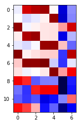

```python
plt.imshow(pd.crosstab(flights_df.Month, flights_df.DayOfWeek),
           cmap='seismic', interpolation='none');
```

**Flight distance histogram:**

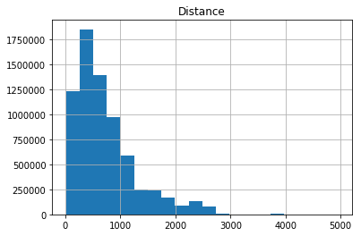

```python
flights_df.hist('Distance', bins=20);
```

**Making a histogram of flight frequency by date.**

```python
flights_df['Date'] = pd.to_datetime(flights_df.rename(
    columns={'DayofMonth': 'Day'})[['Year', 'Month', 'Day']])
```

```python
num_flights_by_date = flights_df.groupby('Date').size()
```

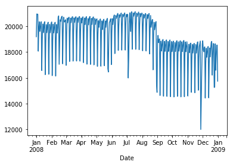

```python
num_flights_by_date.plot();
```

**Do you see a weekly pattern above? And below?**

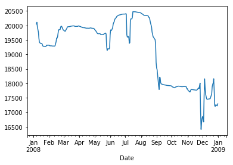

```python
num_flights_by_date.rolling(window=7).mean().plot();
```

**We'll need a new column in our dataset - departure hour, let's create it.**

As we see, `DepTime` is distributed from 1 to 2400 (it is given in the `hhmm` format, check the [column description](https://www.transtats.bts.gov/Fields.asp?Table_ID=236) again). We'll treat departure hour as `DepTime` // 100 (divide by 100 and apply the `floor` function). However, now we'll have both hour 0 and hour 24. Hour 24 sounds strange, we'll set it to be 0 instead (a typical imperfectness of real data, however, you can check that it affects only 521 rows, which is sort of not a big deal). So now values of a new column `DepHour` will be distributed from 0 to 23. There are some missing values, for now we won't fill in them, just ignore them.

```python
flights_df['DepHour'] = flights_df['DepTime'] // 100
flights_df['DepHour'].replace(to_replace=24, value=0, inplace=True)
```

```python
flights_df['DepHour'].describe()
```

```
count    6873482.0
mean           NaN
std            0.0
min            0.0
25%            9.0
50%           13.0
75%           17.0
max           23.0
Name: DepHour, dtype: float64
```

### Now it's your turn. Answer the questions below.

**1. How many unique carriers are there in our dataset?**

- 10
- 15
- 20
- 25

```python
# You code here
flights_df['UniqueCarrier'].nunique()
```

```
20
```

**2. We have both cancelled and completed flights in the datset. Check if there are more completed or cancelled flights. What is the difference?**

*Hint:* Take a look at *Cancelled* to see the categories and *FlightNum* column to calculate unique flights for each category.

- Cancelled overweights completed by 329 flights
- Completed overweights cancelled by 6734860 flights
- Cancelled overweights completed by 671 flights
- Completed overweights cancelled by 11088967 flights

```python
# You code here
#flights_df['Cancelled'].value_counts()

flights_df['Cancelled'].value_counts()[0] - flights_df['Cancelled'].value_counts()[1]
```

```
6734860
```

**3. Find a flight with the longest departure delays and a flight with the longest arrival delay. Do they have the same destination airport, and if yes, what is its code?**

- yes, ATL
- yes, HNL
- yes, MSP
- no

```python
# You code here
flights_df.sort_values(by = 'DepDelay',
    ascending=False).iloc[:3].T
```

|  | 2235378 | 1018798 | 2832617 |
| --- | --- | --- | --- |
| Year | 2008 | 2008 | 2008 |
| Month | 4 | 2 | 5 |
| DayofMonth | 10 | 3 | 6 |
| DayOfWeek | 4 | 7 | 2 |
| DepTime | 724 | 1117 | 2 |
| UniqueCarrier | NW | NW | NW |
| FlightNum | 1699 | 808 | 1107 |
| ArrDelay | 2452 | 2460 | 1951 |
| DepDelay | 2468 | 2456 | 1952 |
| Origin | CLT | HNL | RSW |
| Dest | MSP | MSP | DTW |
| Distance | 930 | 3972 | 1085 |
| Cancelled | 0 | 0 | 0 |
| CancellationCode | NaN | NaN | NaN |
| CarrierDelay | 2436 | 1455 | 1951 |
| WeatherDelay | 0 | 0 | 0 |
| NASDelay | 0 | 4 | 0 |
| SecurityDelay | 0 | 0 | 0 |
| LateAircraftDelay | 17 | 1002 | 0 |
| Date | 2008-04-10 00:00:00 | 2008-02-03 00:00:00 | 2008-05-06 00:00:00 |
| DepHour | 7 | 11 | 0 |

```python
flights_df.sort_values(by = 'ArrDelay',
    ascending=False).iloc[:3].T
```

|  | 1018798 | 2235378 | 2832617 |
| --- | --- | --- | --- |
| Year | 2008 | 2008 | 2008 |
| Month | 2 | 4 | 5 |
| DayofMonth | 3 | 10 | 6 |
| DayOfWeek | 7 | 4 | 2 |
| DepTime | 1117 | 724 | 2 |
| UniqueCarrier | NW | NW | NW |
| FlightNum | 808 | 1699 | 1107 |
| ArrDelay | 2460 | 2452 | 1951 |
| DepDelay | 2456 | 2468 | 1952 |
| Origin | HNL | CLT | RSW |
| Dest | MSP | MSP | DTW |
| Distance | 3972 | 930 | 1085 |
| Cancelled | 0 | 0 | 0 |
| CancellationCode | NaN | NaN | NaN |
| CarrierDelay | 1455 | 2436 | 1951 |
| WeatherDelay | 0 | 0 | 0 |
| NASDelay | 4 | 0 | 0 |
| SecurityDelay | 0 | 0 | 0 |
| LateAircraftDelay | 1002 | 17 | 0 |
| Date | 2008-02-03 00:00:00 | 2008-04-10 00:00:00 | 2008-05-06 00:00:00 |
| DepHour | 11 | 7 | 0 |

**4. Find the carrier that has the greatest number of cancelled flights.**

- AA
- MQ
- WN
- CO

```python
# You code here

flights_df.groupby(['UniqueCarrier'])['Cancelled'].sum().sort_values(
    ascending=False).iloc[:3]
```

```
UniqueCarrier
MQ    18331.0
AA    17440.0
OO    12436.0
Name: Cancelled, dtype: float64
```

**5. Let's examine departure time and consider distribution by hour (column `DepHour` that we've created earlier). Which hour has the highest percentage of flights?**

- 1 am
- 5 am
- 8 am
- 3 pm

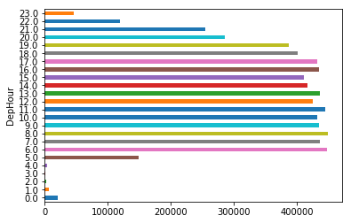

```python
# You code here

flights_df.groupby('DepHour').size().plot(kind='barh');
```

**6. OK, now let's examine cancelled flight distribution by time. Which hour has the least percentage of cancelled flights?**

- 2 am
- 9 pm
- 8 am
- 3 am

```python
# You code here

flights_df.groupby(['DepHour'])['Cancelled'].mean().sort_values().iloc[:3]
```

```
DepHour
3.0     0.000000
13.0    0.000108
12.0    0.000125
Name: Cancelled, dtype: float64
```

**7. Is there any hour that didn't have any cancelled flights at all? Check all that apply.**

- 3
- 19
- 22
- 4

```python
# You code here
flights_df.groupby(['DepHour'])['Cancelled'].sum().sort_values().iloc[:3]
```

```
DepHour
3.0    0
2.0    1
4.0    1
Name: Cancelled, dtype: uint8
```

**8. Find the busiest hour, or in other words, the hour when the number of departed flights reaches its maximum.**

*Hint:* Consider only *completed* flights.

- 4
- 7
- 8
- 17

```python
# You code here
flights_df[flights_df['Cancelled'] == 0] \
    .groupby(['DepHour'])['UniqueCarrier'].count().sort_values(ascending=False)
```

```
DepHour
8.0     449145
6.0     446657
11.0    444643
7.0     436617
13.0    435870
9.0     434794
16.0    433944
17.0    432415
10.0    431403
12.0    424196
14.0    416818
15.0    411053
18.0    400718
19.0    387207
20.0    285940
21.0    254768
5.0     148143
22.0    119594
23.0     46079
0.0      20361
1.0       5857
4.0       3389
2.0       1850
3.0        833
Name: UniqueCarrier, dtype: int64
```

**9. Since we know the departure hour, it might be interesting to examine the average delay for corresponding hour. Are there any cases, when the planes on average departed earlier than they should have done? And if yes, at what departure hours did it happen?**

*Hint:* Consider only *completed* flights.

- no, there are no such cases
- yes, at 5-6 am
- yes, at 9-10 am
- yes, at 2-4 pm

```python
# You code here
flights_df[flights_df['Cancelled'] == 0] \
    .groupby(['DepHour'])['DepDelay'].mean().sort_values(ascending=False)
```

```
DepHour
2.0     122.562500
1.0     111.812500
3.0      95.812500
0.0      70.750000
23.0     60.000000
22.0     38.031250
21.0     23.031250
20.0     22.781250
19.0     16.875000
18.0     15.343750
17.0     13.210938
16.0     11.882812
15.0     11.875000
14.0     10.351562
13.0      8.812500
12.0      7.902344
11.0      6.683594
10.0      5.460938
9.0       3.753906
4.0       3.375000
8.0       1.760742
7.0       0.102539
6.0      -1.629883
5.0      -4.253906
Name: DepDelay, dtype: float16
```

**10. Considering only the completed flights by the carrier, that you have found in Question 4, find the distribution of these flights by hour. At what time does the greatest number of its planes depart?**

- at noon
- at 7 am
- at 8 am
- at 10 am

```python
# You code here
# MQ

flights_df[(flights_df['Cancelled'] == 0) & (flights_df['UniqueCarrier'] == 'MQ')] \
    .groupby(['DepHour'])['UniqueCarrier'].count().sort_values(ascending=False)
```

```
DepHour
10.0    33063
9.0     32596
11.0    31863
13.0    31295
16.0    31276
6.0     30982
15.0    30904
14.0    30149
12.0    30043
7.0     29840
18.0    29362
17.0    28864
8.0     28757
19.0    25493
20.0    18664
5.0     12732
21.0    12086
22.0     3471
23.0      741
0.0       163
1.0        14
2.0         4
Name: UniqueCarrier, dtype: int64
```

**11. Find top-10 carriers in terms of the number of *completed* flights (*UniqueCarrier* column)?**

**Which of the listed below is *not* in your top-10 list?**

- DL
- AA
- OO
- EV

```python
# You code here

flights_df[(flights_df['Cancelled'] == 0)] \
    .groupby(['UniqueCarrier'])['UniqueCarrier'].count().sort_values(ascending=False).head(10)
```

```
UniqueCarrier
WN    1189365
AA     587445
OO     554723
MQ     472362
US     447007
DL     445118
UA     438974
XE     364518
NW     344746
CO     294753
Name: UniqueCarrier, dtype: int64
```

**12. Plot distributions of flight cancellation reasons (*CancellationCode*).**

**What is the most frequent reason for flight cancellation? (Use this [link](https://www.transtats.bts.gov/Fields.asp?Table_ID=236) to translate codes into reasons)**

- Carrier
- Weather conditions
- National Air System
- Security reasons

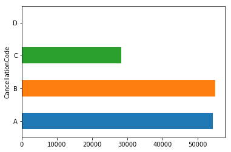

```python
# You code here

#flights_df['CancellationCode'].value_counts()
flights_df.groupby('CancellationCode').size().plot(kind='barh');
```

**13. Which route is the most frequent, in terms of the number of flights?**

(Take a look at *'Origin'* and *'Dest'* features. Consider *A->B* and *B->A* directions as *different* routes)

- New-York – Washington (JFK-IAD)
- San-Francisco – Los-Angeles (SFO-LAX)
- San-Jose – Dallas (SJC-DFW)
- New-York – San-Francisco (JFK-SFO)

```python
# You code here

flights_df.groupby(['Origin','Dest'])['FlightNum'].count().sort_values(ascending=False).head(10)
```

```
Origin  Dest
SFO     LAX     13788
LAX     SFO     13390
OGG     HNL     12383
LGA     BOS     12035
BOS     LGA     12029
HNL     OGG     12014
LAX     LAS     11773
LAS     LAX     11729
LAX     SAN     11257
SAN     LAX     11224
Name: FlightNum, dtype: int64
```

**14. Find top-5 delayed routes (count how many times they were delayed on departure). From all flights on these 5 routes, count all flights with weather conditions contributing to a delay.**

*Hint*: consider only positive delays

- 449
- 539
- 549
- 668

```python
# You code here
flights_df[flights_df['DepDelay'] > 0] \
    .groupby(['Origin','Dest'])['FlightNum'].count().sort_values(ascending=False).head(5)
```

```
Origin  Dest
LAX     SFO     6253
DAL     HOU     5742
SFO     LAX     5322
ORD     LGA     5311
HOU     DAL     5288
Name: FlightNum, dtype: int64
```

```python
flights_df[(((flights_df['Origin'] == 'LAX') & (flights_df['Dest'] == 'SFO')) |
           ((flights_df['Origin'] == 'DAL') & (flights_df['Dest'] == 'HOU')) |
           ((flights_df['Origin'] == 'SFO') & (flights_df['Dest'] == 'LAX')) |
           ((flights_df['Origin'] == 'ORD') & (flights_df['Dest'] == 'LGA')) |
           ((flights_df['Origin'] == 'HOU') & (flights_df['Dest'] == 'DAL'))) &
           flights_df['WeatherDelay'] > 0]
```

|  | Year | Month | DayofMonth | DayOfWeek | DepTime | UniqueCarrier | FlightNum | ArrDelay | DepDelay | Origin | ... | Distance | Cancelled | CancellationCode | CarrierDelay | WeatherDelay | NASDelay | SecurityDelay | LateAircraftDelay | Date | DepHour |
| --- | --- | --- | --- | --- | --- | --- | --- | --- | --- | --- | --- | --- | --- | --- | --- | --- | --- | --- | --- | --- | --- |
| 402 | 2008 | 1 | 3 | 4 | 2008.0 | WN | 646 | 129.0 | 123.0 | LAX | ... | 337 | 0 | NaN | 0.0 | 24.0 | 6.0 | 0.0 | 99.0 | 2008-01-03 | 20.0 |
| 3841 | 2008 | 1 | 4 | 5 | 1440.0 | WN | 680 | 236.0 | 230.0 | LAX | ... | 337 | 0 | NaN | 0.0 | 202.0 | 6.0 | 0.0 | 28.0 | 2008-01-04 | 14.0 |
| 5334 | 2008 | 1 | 4 | 5 | 1946.0 | WN | 442 | 113.0 | 101.0 | SFO | ... | 337 | 0 | NaN | 0.0 | 70.0 | 12.0 | 0.0 | 31.0 | 2008-01-04 | 19.0 |
| 7014 | 2008 | 1 | 5 | 6 | 1604.0 | WN | 656 | 93.0 | 94.0 | LAX | ... | 337 | 0 | NaN | 0.0 | 93.0 | 0.0 | 0.0 | 0.0 | 2008-01-05 | 16.0 |
| 7016 | 2008 | 1 | 5 | 6 | 1533.0 | WN | 776 | 156.0 | 168.0 | LAX | ... | 337 | 0 | NaN | 0.0 | 150.0 | 0.0 | 0.0 | 6.0 | 2008-01-05 | 15.0 |
| 9998 | 2008 | 1 | 6 | 7 | 1549.0 | WN | 656 | 76.0 | 79.0 | LAX | ... | 337 | 0 | NaN | 0.0 | 48.0 | 0.0 | 0.0 | 28.0 | 2008-01-06 | 15.0 |
| 16748 | 2008 | 1 | 8 | 2 | 2220.0 | WN | 593 | 148.0 | 146.0 | LAX | ... | 337 | 0 | NaN | 0.0 | 29.0 | 2.0 | 0.0 | 117.0 | 2008-01-08 | 22.0 |
| 27062 | 2008 | 1 | 11 | 5 | 1207.0 | WN | 680 | 79.0 | 77.0 | LAX | ... | 337 | 0 | NaN | 0.0 | 77.0 | 2.0 | 0.0 | 0.0 | 2008-01-11 | 12.0 |
| 42690 | 2008 | 1 | 16 | 3 | 2204.0 | WN | 62 | 28.0 | 34.0 | HOU | ... | 239 | 0 | NaN | 0.0 | 2.0 | 0.0 | 0.0 | 26.0 | 2008-01-16 | 22.0 |
| 49548 | 2008 | 1 | 18 | 5 | 2144.0 | WN | 60 | 35.0 | 43.0 | HOU | ... | 239 | 0 | NaN | 0.0 | 17.0 | 0.0 | 0.0 | 18.0 | 2008-01-18 | 21.0 |
| 59078 | 2008 | 1 | 21 | 1 | 1528.0 | WN | 918 | 89.0 | 93.0 | LAX | ... | 337 | 0 | NaN | 0.0 | 89.0 | 0.0 | 0.0 | 0.0 | 2008-01-21 | 15.0 |
| 65935 | 2008 | 1 | 23 | 3 | 2232.0 | WN | 619 | 56.0 | 76.0 | LAX | ... | 337 | 0 | NaN | 0.0 | 16.0 | 0.0 | 0.0 | 40.0 | 2008-01-23 | 22.0 |
| 68551 | 2008 | 1 | 24 | 4 | 1956.0 | WN | 53 | 31.0 | 26.0 | DAL | ... | 239 | 0 | NaN | 0.0 | 8.0 | 5.0 | 0.0 | 18.0 | 2008-01-24 | 19.0 |
| 78084 | 2008 | 1 | 27 | 7 | 1047.0 | WN | 12 | 110.0 | 107.0 | HOU | ... | 239 | 0 | NaN | 0.0 | 107.0 | 3.0 | 0.0 | 0.0 | 2008-01-27 | 10.0 |
| 78085 | 2008 | 1 | 27 | 7 | 1050.0 | WN | 16 | 54.0 | 50.0 | HOU | ... | 239 | 0 | NaN | 0.0 | 50.0 | 4.0 | 0.0 | 0.0 | 2008-01-27 | 10.0 |
| 78583 | 2008 | 1 | 27 | 7 | 1527.0 | WN | 918 | 95.0 | 92.0 | LAX | ... | 337 | 0 | NaN | 0.0 | 91.0 | 3.0 | 0.0 | 1.0 | 2008-01-27 | 15.0 |
| 79925 | 2008 | 1 | 27 | 7 | 2116.0 | WN | 688 | 113.0 | 120.0 | SFO | ... | 337 | 0 | NaN | 0.0 | 30.0 | 0.0 | 0.0 | 83.0 | 2008-01-27 | 21.0 |
| 91261 | 2008 | 1 | 31 | 4 | 1038.0 | WN | 7 | 164.0 | 128.0 | DAL | ... | 239 | 0 | NaN | 0.0 | 24.0 | 36.0 | 0.0 | 104.0 | 2008-01-31 | 10.0 |
| 91262 | 2008 | 1 | 31 | 4 | 1027.0 | WN | 9 | 104.0 | 87.0 | DAL | ... | 239 | 0 | NaN | 0.0 | 69.0 | 17.0 | 0.0 | 18.0 | 2008-01-31 | 10.0 |
| 91263 | 2008 | 1 | 31 | 4 | 1051.0 | WN | 11 | 104.0 | 81.0 | DAL | ... | 239 | 0 | NaN | 0.0 | 70.0 | 23.0 | 0.0 | 11.0 | 2008-01-31 | 10.0 |
| 91264 | 2008 | 1 | 31 | 4 | 1052.0 | WN | 15 | 81.0 | 52.0 | DAL | ... | 239 | 0 | NaN | 0.0 | 40.0 | 29.0 | 0.0 | 12.0 | 2008-01-31 | 10.0 |
| 92092 | 2008 | 1 | 31 | 4 | 1746.0 | WN | 97 | 85.0 | 76.0 | LAX | ... | 337 | 0 | NaN | 0.0 | 16.0 | 9.0 | 0.0 | 60.0 | 2008-01-31 | 17.0 |
| 92098 | 2008 | 1 | 31 | 4 | 1957.0 | WN | 1089 | 159.0 | 152.0 | LAX | ... | 337 | 0 | NaN | 0.0 | 134.0 | 7.0 | 0.0 | 18.0 | 2008-01-31 | 19.0 |
| 100547 | 2008 | 1 | 4 | 5 | 1501.0 | XE | 7754 | 448.0 | 406.0 | SFO | ... | 337 | 0 | NaN | 0.0 | 406.0 | 42.0 | 0.0 | 0.0 | 2008-01-04 | 15.0 |
| 101593 | 2008 | 1 | 4 | 5 | 2338.0 | XE | 7784 | 398.0 | 343.0 | LAX | ... | 337 | 0 | NaN | 0.0 | 343.0 | 55.0 | 0.0 | 0.0 | 2008-01-04 | 23.0 |
| 101614 | 2008 | 1 | 25 | 5 | 2340.0 | XE | 7784 | 351.0 | 344.0 | LAX | ... | 337 | 0 | NaN | 224.0 | 120.0 | 7.0 | 0.0 | 0.0 | 2008-01-25 | 23.0 |
| 101625 | 2008 | 1 | 5 | 6 | 2244.0 | XE | 7784 | 158.0 | 175.0 | SFO | ... | 337 | 0 | NaN | 0.0 | 3.0 | 0.0 | 0.0 | 155.0 | 2008-01-05 | 22.0 |
| 101884 | 2008 | 1 | 27 | 7 | 1803.0 | XE | 7794 | 70.0 | 58.0 | SFO | ... | 337 | 0 | NaN | 0.0 | 18.0 | 12.0 | 0.0 | 40.0 | 2008-01-27 | 18.0 |
| 102168 | 2008 | 1 | 4 | 5 | 2316.0 | XE | 7812 | 154.0 | 105.0 | LAX | ... | 337 | 0 | NaN | 0.0 | 17.0 | 49.0 | 0.0 | 88.0 | 2008-01-04 | 23.0 |
| 102187 | 2008 | 1 | 25 | 5 | 4.0 | XE | 7812 | 155.0 | 154.0 | LAX | ... | 337 | 0 | NaN | 0.0 | 154.0 | 1.0 | 0.0 | 0.0 | 2008-01-25 | 0.0 |
| ... | ... | ... | ... | ... | ... | ... | ... | ... | ... | ... | ... | ... | ... | ... | ... | ... | ... | ... | ... | ... | ... |
| 6900775 | 2008 | 12 | 21 | 7 | 1306.0 | AA | 374 | 26.0 | 41.0 | ORD | ... | 733 | 0 | NaN | 0.0 | 8.0 | 0.0 | 0.0 | 18.0 | 2008-12-21 | 13.0 |
| 6900777 | 2008 | 12 | 23 | 2 | 1518.0 | AA | 374 | 203.0 | 173.0 | ORD | ... | 733 | 0 | NaN | 0.0 | 33.0 | 30.0 | 0.0 | 140.0 | 2008-12-23 | 15.0 |
| 6900778 | 2008 | 12 | 24 | 3 | 1327.0 | AA | 374 | 54.0 | 62.0 | ORD | ... | 733 | 0 | NaN | 0.0 | 18.0 | 0.0 | 0.0 | 36.0 | 2008-12-24 | 13.0 |
| 6900937 | 2008 | 12 | 1 | 1 | 1255.0 | AA | 378 | 131.0 | 125.0 | ORD | ... | 733 | 0 | NaN | 0.0 | 18.0 | 6.0 | 0.0 | 107.0 | 2008-12-01 | 12.0 |
| 6900944 | 2008 | 12 | 9 | 2 | 1104.0 | AA | 378 | 30.0 | 14.0 | ORD | ... | 733 | 0 | NaN | 0.0 | 14.0 | 16.0 | 0.0 | 0.0 | 2008-12-09 | 11.0 |
| 6900949 | 2008 | 12 | 15 | 1 | 1202.0 | AA | 378 | 51.0 | 72.0 | ORD | ... | 733 | 0 | NaN | 14.0 | 37.0 | 0.0 | 0.0 | 0.0 | 2008-12-15 | 12.0 |
| 6900957 | 2008 | 12 | 24 | 3 | 1156.0 | AA | 378 | 80.0 | 66.0 | ORD | ... | 733 | 0 | NaN | 0.0 | 48.0 | 14.0 | 0.0 | 18.0 | 2008-12-24 | 11.0 |
| 6901026 | 2008 | 12 | 1 | 1 | 1236.0 | AA | 382 | 180.0 | 166.0 | ORD | ... | 733 | 0 | NaN | 0.0 | 24.0 | 14.0 | 0.0 | 142.0 | 2008-12-01 | 12.0 |
| 6901031 | 2008 | 12 | 6 | 6 | 1057.0 | AA | 382 | 69.0 | 67.0 | ORD | ... | 733 | 0 | NaN | 33.0 | 34.0 | 2.0 | 0.0 | 0.0 | 2008-12-06 | 10.0 |
| 6901048 | 2008 | 12 | 23 | 2 | 1054.0 | AA | 382 | 73.0 | 64.0 | ORD | ... | 733 | 0 | NaN | 0.0 | 31.0 | 9.0 | 0.0 | 33.0 | 2008-12-23 | 10.0 |
| 6901049 | 2008 | 12 | 24 | 3 | 1056.0 | AA | 382 | 73.0 | 66.0 | ORD | ... | 733 | 0 | NaN | 0.0 | 45.0 | 7.0 | 0.0 | 21.0 | 2008-12-24 | 10.0 |
| 6901051 | 2008 | 12 | 26 | 5 | 1114.0 | AA | 382 | 88.0 | 84.0 | ORD | ... | 733 | 0 | NaN | 0.0 | 18.0 | 4.0 | 0.0 | 66.0 | 2008-12-26 | 11.0 |
| 6901142 | 2008 | 12 | 1 | 1 | 1144.0 | AA | 386 | 184.0 | 164.0 | ORD | ... | 733 | 0 | NaN | 0.0 | 164.0 | 20.0 | 0.0 | 0.0 | 2008-12-01 | 11.0 |
| 6901154 | 2008 | 12 | 15 | 1 | 929.0 | AA | 386 | 32.0 | 29.0 | ORD | ... | 733 | 0 | NaN | 0.0 | 8.0 | 3.0 | 0.0 | 21.0 | 2008-12-15 | 9.0 |
| 6901160 | 2008 | 12 | 22 | 1 | 921.0 | AA | 386 | 27.0 | 21.0 | ORD | ... | 733 | 0 | NaN | 0.0 | 21.0 | 6.0 | 0.0 | 0.0 | 2008-12-22 | 9.0 |
| 6901161 | 2008 | 12 | 23 | 2 | 915.0 | AA | 386 | 19.0 | 15.0 | ORD | ... | 733 | 0 | NaN | 0.0 | 15.0 | 4.0 | 0.0 | 0.0 | 2008-12-23 | 9.0 |
| 6901162 | 2008 | 12 | 24 | 3 | 938.0 | AA | 386 | 49.0 | 38.0 | ORD | ... | 733 | 0 | NaN | 0.0 | 16.0 | 11.0 | 0.0 | 22.0 | 2008-12-24 | 9.0 |
| 6901164 | 2008 | 12 | 26 | 5 | 954.0 | AA | 386 | 60.0 | 54.0 | ORD | ... | 733 | 0 | NaN | 0.0 | 20.0 | 6.0 | 0.0 | 34.0 | 2008-12-26 | 9.0 |
| 6901351 | 2008 | 12 | 1 | 1 | 950.0 | AA | 392 | 126.0 | 120.0 | ORD | ... | 733 | 0 | NaN | 0.0 | 120.0 | 6.0 | 0.0 | 0.0 | 2008-12-01 | 9.0 |
| 6901365 | 2008 | 12 | 15 | 1 | 815.0 | AA | 392 | 33.0 | 15.0 | ORD | ... | 733 | 0 | NaN | 0.0 | 15.0 | 18.0 | 0.0 | 0.0 | 2008-12-15 | 8.0 |
| 6901367 | 2008 | 12 | 17 | 3 | 827.0 | AA | 392 | 26.0 | 27.0 | ORD | ... | 733 | 0 | NaN | 0.0 | 26.0 | 0.0 | 0.0 | 0.0 | 2008-12-17 | 8.0 |
| 6901373 | 2008 | 12 | 23 | 2 | 811.0 | AA | 392 | 34.0 | 21.0 | ORD | ... | 733 | 0 | NaN | 0.0 | 21.0 | 13.0 | 0.0 | 0.0 | 2008-12-23 | 8.0 |
| 6901375 | 2008 | 12 | 26 | 5 | 910.0 | AA | 392 | 87.0 | 80.0 | ORD | ... | 733 | 0 | NaN | 0.0 | 80.0 | 7.0 | 0.0 | 0.0 | 2008-12-26 | 9.0 |
| 6901412 | 2008 | 12 | 1 | 1 | 709.0 | AA | 394 | 62.0 | 24.0 | ORD | ... | 733 | 0 | NaN | 0.0 | 24.0 | 38.0 | 0.0 | 0.0 | 2008-12-01 | 7.0 |
| 6901422 | 2008 | 12 | 15 | 1 | 801.0 | AA | 394 | 81.0 | 76.0 | ORD | ... | 733 | 0 | NaN | 0.0 | 76.0 | 5.0 | 0.0 | 0.0 | 2008-12-15 | 8.0 |
| 6901428 | 2008 | 12 | 23 | 2 | 709.0 | AA | 394 | 20.0 | 24.0 | ORD | ... | 733 | 0 | NaN | 0.0 | 20.0 | 0.0 | 0.0 | 0.0 | 2008-12-23 | 7.0 |
| 6901463 | 2008 | 12 | 1 | 1 | 615.0 | AA | 398 | 21.0 | 15.0 | ORD | ... | 733 | 0 | NaN | 0.0 | 15.0 | 6.0 | 0.0 | 0.0 | 2008-12-01 | 6.0 |
| 6901475 | 2008 | 12 | 15 | 1 | 614.0 | AA | 398 | 22.0 | 14.0 | ORD | ... | 733 | 0 | NaN | 0.0 | 14.0 | 8.0 | 0.0 | 0.0 | 2008-12-15 | 6.0 |
| 6901483 | 2008 | 12 | 24 | 3 | 614.0 | AA | 398 | 18.0 | 14.0 | ORD | ... | 733 | 0 | NaN | 0.0 | 14.0 | 4.0 | 0.0 | 0.0 | 2008-12-24 | 6.0 |
| 6901485 | 2008 | 12 | 26 | 5 | 646.0 | AA | 398 | 60.0 | 46.0 | ORD | ... | 733 | 0 | NaN | 0.0 | 46.0 | 14.0 | 0.0 | 0.0 | 2008-12-26 | 6.0 |

668 rows × 21 columns

**15. Examine the hourly distribution of departure times. Choose all correct statements:**

- Flights are normally distributed within time interval [0-23] (Search for: Normal distribution, bell curve).
- Flights are uniformly distributed within time interval [0-23].
- In the period from 0 am to 4 am there are considerably less flights than from 7 pm to 8 pm.

```python
# You code here
#flights_df['DepHour'].value_counts()
%config InlineBackend.figure_format = 'svg'
sns.distplot(flights_df[(flights_df['DepHour'].notnull())]['DepHour']);
```

[figure not shown]

```python
sns.boxplot(x='DepHour', data=flights_df[(flights_df['DepHour'].notnull())]);
```

[figure not shown]

**16. Show how the number of flights changes through time (on the daily/weekly/monthly basis) and interpret the findings.**

**Choose all correct statements:**

- The number of flights during weekends is less than during weekdays (working days).
- The lowest number of flights is on Sunday.
- There are less flights during winter than during summer.

*Hint*: Look for official meteorological winter months for the Northern Hemisphere.

```python
# You code here
flights_df.groupby('DayOfWeek').size().plot(kind='barh');
```

[figure not shown]

```python
flights_df.groupby('Month').size().plot(kind='barh');
```

[figure not shown]

A and C

**17. Examine the distribution of cancellation reasons with time. Make a bar plot of cancellation reasons aggregated by months.**

**Choose all correct statements:**

- October has the lowest number of cancellations due to weather.
- The highest number of cancellations in September is due to Security reasons.
- April's top cancellation reason is carriers.
- Flights cancellations due to National Air System are more frequent than those due to carriers.

```python
# You code here

sns.countplot(x='Month', hue='CancellationCode', data=flights_df);
```

[figure not shown]

A, C

**18. Which month has the greatest number of cancellations due to Carrier?**

- May
- January
- September
- April

```python
# You code here
```

Grafico de arriba. D (April)

**19. Identify the carrier with the greatest number of cancellations due to carrier in the corresponding month from the previous question.**

- 9E
- EV
- HA
- AA

```python
# You code here
sns.countplot(x='UniqueCarrier', hue='CancellationCode', data=flights_df[flights_df['Month'] == 4]);
```

[figure not shown]

**20. Examine median arrival and departure delays (in time) by carrier. Which carrier has the lowest median delay time for both arrivals and departures? Leave only non-negative values of delay times ('ArrDelay', 'DepDelay'). ([Boxplots](https://seaborn.pydata.org/generated/seaborn.boxplot.html) can be helpful in this exercise, as well as it might be a good idea to remove outliers in order to build nice graphs. You can exclude delay time values higher than a corresponding .95 percentile).**

- EV
- OO
- AA
- AQ

```python
#

flights_df[flights_df.ArrDelay > 0].groupby(['UniqueCarrier'])['ArrDelay'].median().sort_values().head(10)
```

```
UniqueCarrier
AQ     5.0
HA     7.0
F9    12.0
WN    13.0
OO    13.0
DL    13.0
FL    14.0
AS    14.0
US    14.0
NW    14.0
Name: ArrDelay, dtype: float16
```

```python
flights_df[flights_df.ArrDelay > 0].groupby(['UniqueCarrier'])['DepDelay'].median().sort_values().head(10)
```

```
UniqueCarrier
AQ    2.0
HA    2.0
NW    3.0
US    5.0
DL    5.0
9E    7.0
F9    7.0
OH    8.0
FL    8.0
AS    8.0
Name: DepDelay, dtype: float16
```